## Shayna Hay, CMSC320, Project 2, 18 March 2022

```python
import sqlite3
import pandas as pd
import numpy as np
import matplotlib.pyplot as plt
```

# Part 1- Wrangling

## Problem 1

```python
sqlite_file = 'lahman2014.sqlite'
conn = sqlite3.connect(sqlite_file)

salary_query = "SELECT yearID, sum(salary) as total_payroll, teamID FROM Salaries GROUP BY yearID, teamID"
winning_query = "SELECT yearID, teamID, W as wins, G as games FROM Teams GROUP BY yearID, teamID"

salaries = pd.read_sql(salary_query, conn)
winnings = pd.read_sql(winning_query, conn)

winnings["win_perc"] = (winnings['wins'] / winnings['games'] * 100)

table = pd.merge(winnings, salaries, how='inner', on=['teamID','yearID'])

table
```

|  | yearID | teamID | wins | games | win_perc | total_payroll |
| --- | --- | --- | --- | --- | --- | --- |
| 0 | 1985 | ATL | 66 | 162 | 40.740741 | 14807000.0 |
| 1 | 1985 | BAL | 83 | 161 | 51.552795 | 11560712.0 |
| 2 | 1985 | BOS | 81 | 163 | 49.693252 | 10897560.0 |
| 3 | 1985 | CAL | 90 | 162 | 55.555556 | 14427894.0 |
| 4 | 1985 | CHA | 85 | 163 | 52.147239 | 9846178.0 |
| ... | ... | ... | ... | ... | ... | ... |
| 853 | 2014 | SLN | 90 | 162 | 55.555556 | 120693000.0 |
| 854 | 2014 | TBA | 77 | 162 | 47.530864 | 72689100.0 |
| 855 | 2014 | TEX | 67 | 162 | 41.358025 | 112255059.0 |
| 856 | 2014 | TOR | 83 | 162 | 51.234568 | 109920100.0 |
| 857 | 2014 | WAS | 96 | 162 | 59.259259 | 131983680.0 |

858 rows × 6 columns

Code Description: Within this code, I was able to use SQL to scrape the needed data for a table representing the total payroll and winning percentage for each team for each year. I was able to do this by groupign within the SQL by yearID and teamID for salaries and teamID. I was then able to read the SQL and input it as a dataframe. I created a new column where I then calculated the winning percentage. I was then able to merge the salaries and winnings table using an inner merge. I utilized an inner merge because incase there are any teams/years that do not have any data for total_payroll AND winning percentage, we do not want to use this information. This is because we are analyzing if there is a correlation between the two, so if we do not have information for one of them (no matter the reason) we do not want to utilize that information.

# Part 2- Exploratory Data Analysis

## Problem 2

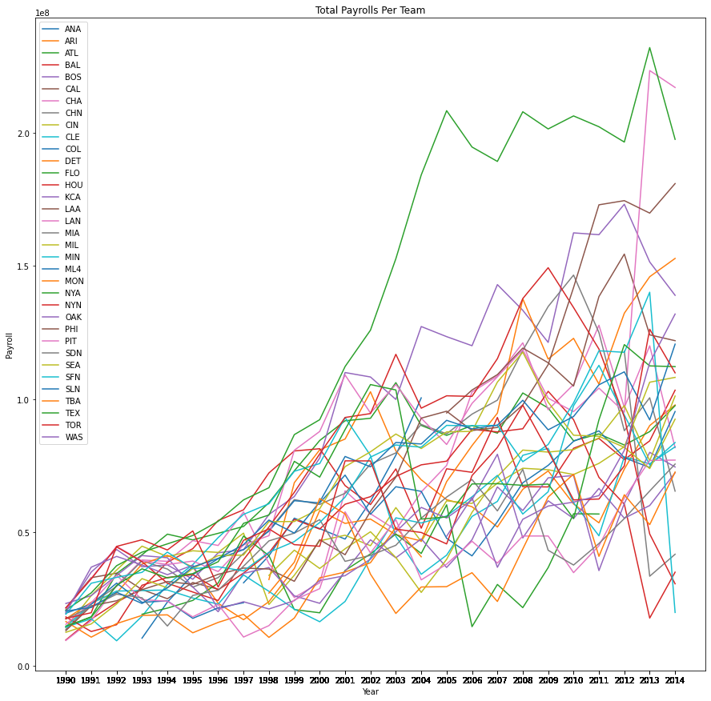

```python
greater_90 = table.copy(deep=True)

for index, row in greater_90.iterrows():
    if row['yearID'] < 1990 or row['yearID'] > 2014:
        greater_90.drop(labels = [index], inplace = True, axis = 0)


groups = greater_90.groupby(['teamID'])

fig, ax = plt.subplots()

for name, group in groups:
    group.plot(figsize=(15,15),ax=ax,x='yearID', y='total_payroll', label=name)

plt.xticks(greater_90['yearID'])
plt.title("Total Payrolls Per Team")
plt.xlabel("Year")
plt.ylabel("Payroll")
plt.show()
```

Code Description: In order to create a plot that showed the distribution of payrolls across teams during the time period of 1990 - 20014, I had to start with filtering the dataframe. I did this by making a deep copy of the table created in problem 1, and removing rows where the year is less than 1990 or greater than 2014. I then grouped all of the rows by teams and plotted each individual table on its own line. I set the labels to be equal to the team name, set the xaxis to be the year, the yaxis to be the Payroll, and the name of the table to be the total payrolls per team.

## Question 1

Based on these plots, some statements that I am able to make about the distribution of payrolls conditions on time based on these plots is realted to the distribution. In the earlier years, we are able to see that there is not much variabilty between payroll based on each team. As the years go on, there becomes to have more variability but majority of the teams stay within the same general payroll range other than 2 to 3 outliers. Overall though, as time goes on, the trend of payroll did increase for all the teams combined.

## Problem 3

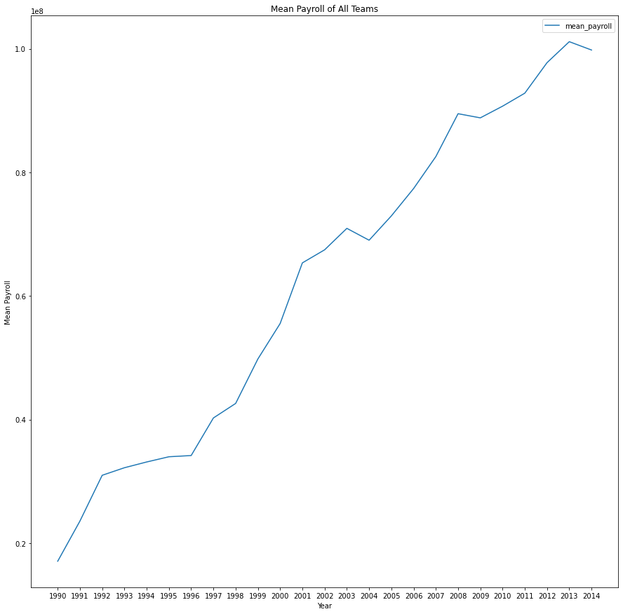

```python
groups = greater_90.groupby("yearID")

mean_tab = pd.DataFrame(columns=['yearID','mean_payroll'])

for name, group in groups:
    mean_tab.loc[len(mean_tab.index)] = [name, group['total_payroll'].mean()]

mean_tab.plot(x='yearID', y='mean_payroll',figsize=(15,15))

plt.xticks(mean_tab['yearID'])
plt.title("Mean Payroll of All Teams")
plt.xlabel("Year")
plt.ylabel("Mean Payroll")
plt.show()
```

Code Description: In order to show that as time goes on, the trend of payroll increases for all the teams combined, I decided to create a plot that shows the mean payroll of all the teams over time. To do this I started by grouping the table of data with the yearID being between greater than 1990 by the yearID. I then went through and added the mean of each group to a new datafram with the mean payroll and the yearID. I then plotted that new dataframe.

## Problem 4

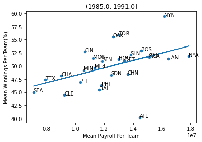

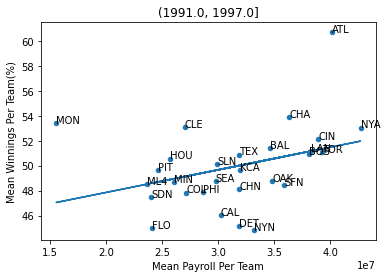

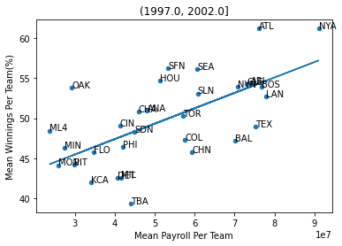

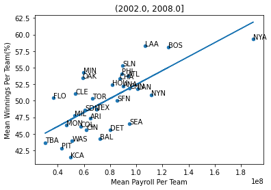

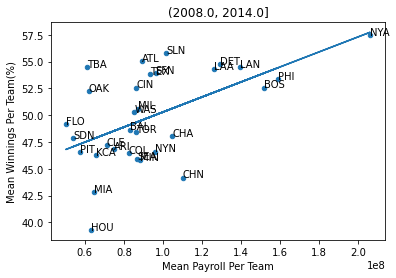

```python
table['bins'] = pd.cut(x=table['yearID'], bins=5, precision = 0)

groups = table.groupby(['bins'])

for name, group in groups:
    frame = pd.DataFrame(columns=['teamID','mean_payroll', 'mean_winnings'])
    teams = group.groupby(['teamID'])

    for name1, group1 in teams:
        frame.loc[len(frame.index)] = [name1,group1['total_payroll'].mean(),group1['win_perc'].mean()]

    frame.plot.scatter(x='mean_payroll', y='mean_winnings', title = name, xlabel="Mean Payroll Per Team", ylabel="Mean Winnings Per Team(%)")

    for i, txt in enumerate(frame['teamID']):
        plt.annotate(txt, (frame['mean_payroll'][i], frame['mean_winnings'][i]))

    m,b = np.polyfit(frame['mean_payroll'], frame['mean_winnings'],1)
    plt.plot(frame['mean_payroll'], m*frame['mean_payroll']+b)
```

Code Description: In order to represent the mean winnings and mean payroll over 5 separate time periods, I utilized the pandas cut method to create 5 even sized bins. I then added this as a column to the original table created in problem 1. I then grouped the table by the bins created before. Then, inorder to create a table of the mean of each individual team, I looped through each of the bin groups and grouped that again by the teamID. This allowed me to then grab the mean winnings an payroll for that team for the timeframe. I then added these two values, alongside the teamID, to a new dataframe. I then created a scatterplot out of this new dataframe, added a linear regression line, and added text to each point on the scaterplot to represent the teamID. This allowed us to compare and contrast each team and each trend over a period of time.

## Question 2

Utilizing the plots above, there is a lot that I can analyze about team payrolls across these period. When analyzing the linear regression lines across the different plots, it seems as if almost all of them have around the same slope. There is no table that seems to have a significatly larger slope than others. When it comes to any teams that standout for being particularly good at paying for wins across these time periods, Boston and the Yankees seem to stand out. Across every single graph, these two teams considtanly are on the higherside of the mean payroll. In addition, Boston always has about 50% or above mean winnings, and the Yankees consistantly had a the highest payroll and it seeems as if they had a relatively high winning percentage as well. When looking at Oakland A's spending efficiency across these time periods, in the beginning years we can see that they were on the average side of the mean payroll compared to other teams. While this payroll did payoff, they slowly increased their payroll as time went on whereas other teams increased it exponentially. That did not effect their winning percentage though. Even though their mean payroll increased in smaller amounts and became on the lower side, their win percentage continued to be on the higher side compared to other teams.

# Part 3- Data Transformations

## Problem 5

```python
teams = table.groupby(['yearID'])

frame = pd.DataFrame(columns=['yearID','mean_payroll', 'sd_payroll'])

for name, group in teams:
    mean = group['total_payroll'].mean()
    sd = group['total_payroll'].std()
    frame.loc[len(frame.index)] = [name,group['total_payroll'].mean(),group['total_payroll'].std()]

table =table.merge(frame, on=['yearID'])
table['standardized_payroll'] = (((table['total_payroll'])-(table['mean_payroll'])) / table['sd_payroll'])
table
```

|  | yearID | teamID | wins | games | win_perc | total_payroll | bins | mean_payroll | sd_payroll | standardized_payroll |
| --- | --- | --- | --- | --- | --- | --- | --- | --- | --- | --- |
| 0 | 1985 | ATL | 66 | 162 | 40.740741 | 14807000.0 | (1985.0, 1991.0] | 1.007557e+07 | 2.470845e+06 | 1.914905 |
| 1 | 1985 | BAL | 83 | 161 | 51.552795 | 11560712.0 | (1985.0, 1991.0] | 1.007557e+07 | 2.470845e+06 | 0.601068 |
| 2 | 1985 | BOS | 81 | 163 | 49.693252 | 10897560.0 | (1985.0, 1991.0] | 1.007557e+07 | 2.470845e+06 | 0.332678 |
| 3 | 1985 | CAL | 90 | 162 | 55.555556 | 14427894.0 | (1985.0, 1991.0] | 1.007557e+07 | 2.470845e+06 | 1.761474 |
| 4 | 1985 | CHA | 85 | 163 | 52.147239 | 9846178.0 | (1985.0, 1991.0] | 1.007557e+07 | 2.470845e+06 | -0.092838 |
| ... | ... | ... | ... | ... | ... | ... | ... | ... | ... | ... |
| 853 | 2014 | SLN | 90 | 162 | 55.555556 | 120693000.0 | (2008.0, 2014.0] | 9.980002e+07 | 4.570505e+07 | 0.457126 |
| 854 | 2014 | TBA | 77 | 162 | 47.530864 | 72689100.0 | (2008.0, 2014.0] | 9.980002e+07 | 4.570505e+07 | -0.593171 |
| 855 | 2014 | TEX | 67 | 162 | 41.358025 | 112255059.0 | (2008.0, 2014.0] | 9.980002e+07 | 4.570505e+07 | 0.272509 |
| 856 | 2014 | TOR | 83 | 162 | 51.234568 | 109920100.0 | (2008.0, 2014.0] | 9.980002e+07 | 4.570505e+07 | 0.221422 |
| 857 | 2014 | WAS | 96 | 162 | 59.259259 | 131983680.0 | (2008.0, 2014.0] | 9.980002e+07 | 4.570505e+07 | 0.704160 |

858 rows × 10 columns

## Problem 6

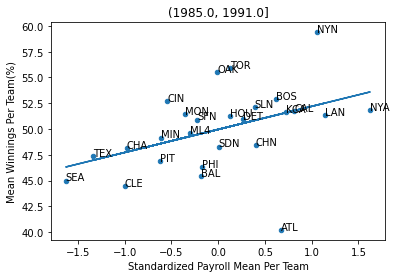

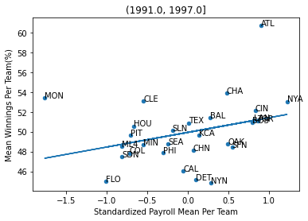

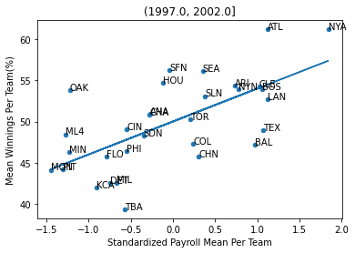

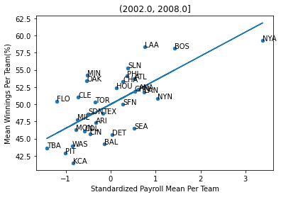

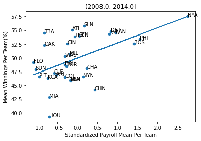

```python
groups = table.groupby(['bins'])

for name, group in groups:
    frame = pd.DataFrame(columns=['teamID','standardized_payroll', 'mean_winnings'])
    teams = group.groupby(['teamID'])

    for name1, group1 in teams:
        frame.loc[len(frame.index)] = [name1,group1['standardized_payroll'].mean(),group1['win_perc'].mean()]

    frame.plot.scatter(x='standardized_payroll', y='mean_winnings', title = name, xlabel="Standardized Payroll Mean Per Team", ylabel="Mean Winnings Per Team(%)")

    for i, txt in enumerate(frame['teamID']):
        plt.annotate(txt, (frame['standardized_payroll'][i], frame['mean_winnings'][i]))

    m,b = np.polyfit(frame['standardized_payroll'], frame['mean_winnings'],1)
    plt.plot(frame['standardized_payroll'], m*frame['standardized_payroll']+b)
```

Code Description: In this code, I did the same exact thing as in problem 4 except instead of using the total payroll, I used the standardized payroll. The description is the same as above.

## Question 3

The plots from Problem 4 and Problem 6 reflect the transformation I did on the payroll variable because the x axis for all of the plots are roughly the same in 6. After standardizing the payroll, we were able to directly compare all of the separate 5 graphs. In Problem 4, the x axis is raised to separate powers, is in different ranges, and is difficult to analzye across the years. After standardizing the payroll, the 5 separate plots are more comparable.

## Problem 7

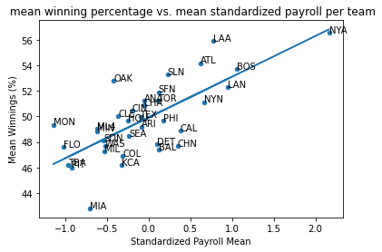

```python
teams = table.groupby(['teamID'])

comp = pd.DataFrame(columns=['teamID','mean_sd_payroll', 'mean_winning_perc'])

for name, group in teams:
     comp.loc[len(comp.index)] = [name,group['standardized_payroll'].mean(),group['win_perc'].mean()]

comp.plot.scatter(x='mean_sd_payroll', y='mean_winning_perc', title = " mean winning percentage vs. mean standardized payroll per team", xlabel="Standardized Payroll Mean", ylabel="Mean Winnings (%)")
for i, txt in enumerate(comp['teamID']):
        plt.annotate(txt, (comp['mean_sd_payroll'][i], comp['mean_winning_perc'][i]))

m,b = np.polyfit(comp['mean_sd_payroll'], comp['mean_winning_perc'],1)
plt.plot(comp['mean_sd_payroll'], m*comp['mean_sd_payroll']+b)

table['expected_win_pct'] = 50 + 2.5 * table['standardized_payroll']
plt.show()
```

Code Description: In order to create a scatter plot for the mean winning percentage and the mean standardized payroll per team, I needed to first group the original table by teamID. I did this so I could easily find the mean winning percentage and the mean standardized payroll for team. Once I got this information, I was then able to put it in its own dataframe. After completing this newly created dataframe. I directly plotted it, added in text for the teamID, and added in a line of regression. Finally I created a new column in the original table which represents the expected win percentage based on the results from the plot

## Problem 8

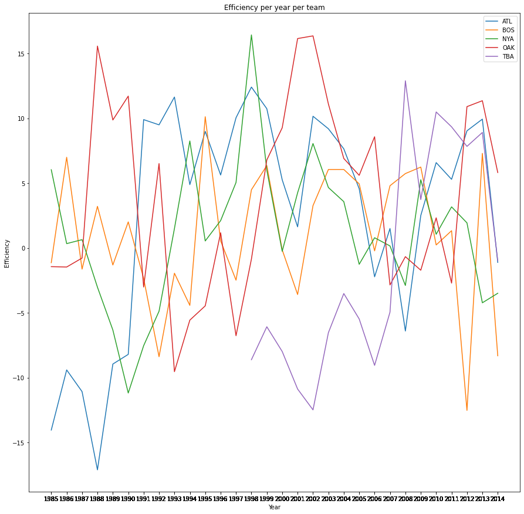

```python
table['efficiency'] = table['win_perc'] - table['expected_win_pct']

groups = table.groupby(['teamID'])

fig, ax = plt.subplots()

for name, group in groups:
    if name == 'OAK' or name == 'BOS' or name == 'NYA' or name == 'ATL' or name == 'TBA':
        group.plot(figsize=(15,15),ax=ax,x='yearID', y='efficiency', label=name)

plt.xticks(table['yearID'])
plt.title("Efficiency per year per team")
plt.xlabel("Year")
plt.ylabel("Efficiency")
plt.show()
```

Code Description: Inorder to compare teams efficiently, I created a column which hold the efficiency of that team for that year. I calculated this by subtracting the expectded win percentage from the actual win percentage. I then grouped the table by teamID so I can analyze each team individual over the years. I chose to analyze Oakland, the New York Yankees, Boston, Atlanta and Tampa Bay. I did this by looping through the groups, and if the group was one of interest, I plotted it with the year in the x axis, and the efficency in the y. I then labeled it based off of the teamID. This showed me all the teams on the same plot so I can directly compare them

## Question 4

From this plot, I am able to learn a lot more compared to the plots created in question 2 and question 3. This is because instead of looking at their payroll compared to winnings and inferencing ourselves, we have a set equation and a direct way of comparing. Here we know what we would expect the winning percentage to be and can see if the payroll is paying off and or if there even is a consistant correlation between payroll and winnings. This is something we were not sure about in the other problems and could be interpreted differently across different people. In addition, the plots from the previous questions mainly showed us the teams that stood out as having a higher pay roll but not how consistently the teams standout from the line of linear regression. From the plot above, we can see that during the Moneyball period (2002), Oakland's efficieny was extremely high. This plot does not tell us the payroll of what oakland spent during this year, but it does tell us that that year Oakland won 15% more games than was expected of them which is extremely good.